[figure not shown]

# NFL: Which Plays Win Games?

Author: Jonathan Zuramski

### Introduction

The National Football League is the United States’ premiere football league. The NFL is a highly competitive league containing 32 teams, who are looking to optimize their team’s strategy to win as many games as possible and move onto the playoffs. NFL games outcomes are highly dependent on the play-by-play performance of team’s during a game. Today we are going to investigate which kind of plays generally yield the best performance. Will going for a smaller amount of large play with lots of yardage, or going for short consistent plays end up being more advantageous? We will be looking at the play-by-play data from the 2019 NFL seasons and 2019 Game Data, which can be found [here](https://github.com/ryurko/nflscrapR-data) in CSV form. (file names are reg_pbp_2019.csv and reg_games_2019.csv, I could not upload reg_pbp_2019.csv to github because it was too large)

In this tutorial, our goal is to go through the step by step process of data curation, parsing, and management. We are going to look at analysis of our data through machine learning to provide insights in the data to figure out an overall outcome. We wil be using Python 3 as well as slew of libraries

## Prerequisite Knowledge

Before we start, we will need to know what the two play types we are looking at and how a play functions in football. A play starts off with the Quarterback (the position that throws the ball) starting the play. Before the play is started the play type is decided by a coach or the Quarterback based on what is happening previously. A pass play involves the Quarterback throwing to a receiver downfield. A rush or run is when the Quarterback hands the ball off to a running back who then runs down towards the endzone. There I will be using rush and run interchangeable. In football there are downs; which is the number of attempts to get the ball in the other teams endzone. You only get 4 attempts, unless you move forward ten yards, then the downs are reset. Yards and yardage refers the length down the field, a football field is 100 yards from the bottom of the endzone of one side to the bottom of the other endzone.

The question we are looking at is what play type is better? Getting shorter plays that are more consistent could be better as you have more of a chance of getting the 1st down after reaching 10 yards. But longer plays could give you more chances to get the first down in one shot. We will see.

## Libraries and Imports

We are going to need some Python Libraries to manage our data. We will use [pandas](https://pandas.pydata.org/) to organize our data inside a dataframe to further be processed (we include [numpy](https://numpy.org/) to be able to use things like NaN within dataframes). [Matplotlib](https://matplotlib.org/) will be used for creating visuals to better represent the meaning behind the data. [Scikit-learn](https://scikit-learn.org/stable/) will be used for machine learning and regression to show trends in the data. We will use more libraries, but these are the most important. If any preprocessing of the data needs to be done such as chopping off headers or deleting any unwanted info before reading it in go ahead and do that now. With the CSV we are using we will import it then drop rows we don't need once its in the dataframe!

```python
import numpy as np
import pandas as pd
from sklearn.linear_model import LinearRegression
import matplotlib.pyplot as plt
import plotnine
from plotnine import *
import seaborn as sns
from sklearn.linear_model import Ridge
import statsmodels.api as sm
import statsmodels.formula.api as smf
from sklearn.model_selection import train_test_split
from sklearn import linear_model
from sklearn import preprocessing
from statsmodels.stats import diagnostic as diag
```

# Data Parsing

Now that we have all the necessary libraries we can go ahead and import our data into an organized format that is easy to work with. There are multiple ways to pull data in, but using a CSV is the easiest because that data is already formatted. There are other methods such as pulling data from a site with a get request then parsing the HTML, but today we are sticking with CSV’s

After parsing the data I like to use the data frame method .head() which gives the first couple rows, making it easier to see how the data frame is laid out.

```python
#reading in CSV's into a panda data frame

rawdata2019 = pd.read_csv('reg_pbp_2019.csv')
win_data2019 = pd.read_csv('reg_games_2019.csv')

#displays the first 5 rows so you can get an understanding of the dataframe.
rawdata2019.head()
```

|  | play_id | game_id | home_team | away_team | posteam | posteam_type | defteam | side_of_field | yardline_100 | game_date | ... | penalty_player_id | penalty_player_name | penalty_yards | replay_or_challenge | replay_or_challenge_result | penalty_type | defensive_two_point_attempt | defensive_two_point_conv | defensive_extra_point_attempt | defensive_extra_point_conv |
| --- | --- | --- | --- | --- | --- | --- | --- | --- | --- | --- | --- | --- | --- | --- | --- | --- | --- | --- | --- | --- | --- |
| 0 | 35 | 2019090500 | CHI | GB | GB | away | CHI | CHI | 35.0 | 2019-09-05 | ... | NaN | NaN | NaN | 0 | NaN | NaN | 0.0 | 0.0 | 0.0 | 0.0 |
| 1 | 50 | 2019090500 | CHI | GB | GB | away | CHI | GB | 75.0 | 2019-09-05 | ... | NaN | NaN | NaN | 0 | NaN | NaN | 0.0 | 0.0 | 0.0 | 0.0 |
| 2 | 71 | 2019090500 | CHI | GB | GB | away | CHI | GB | 75.0 | 2019-09-05 | ... | NaN | NaN | NaN | 0 | NaN | NaN | 0.0 | 0.0 | 0.0 | 0.0 |
| 3 | 95 | 2019090500 | CHI | GB | GB | away | CHI | GB | 75.0 | 2019-09-05 | ... | NaN | NaN | NaN | 0 | NaN | NaN | 0.0 | 0.0 | 0.0 | 0.0 |
| 4 | 125 | 2019090500 | CHI | GB | GB | away | CHI | GB | 85.0 | 2019-09-05 | ... | NaN | NaN | NaN | 0 | NaN | NaN | 0.0 | 0.0 | 0.0 | 0.0 |

5 rows × 256 columns

```python
win_data2019.head()
```

|  | type | game_id | home_team | away_team | week | season | state_of_game | game_url | home_score | away_score |
| --- | --- | --- | --- | --- | --- | --- | --- | --- | --- | --- |
| 0 | reg | 2019090500 | CHI | GB | 1 | 2019 | POST | http://www.nfl.com/liveupdate/game-center/2019... | 3 | 10 |
| 1 | reg | 2019090800 | CAR | LA | 1 | 2019 | POST | http://www.nfl.com/liveupdate/game-center/2019... | 27 | 30 |
| 2 | reg | 2019090806 | PHI | WAS | 1 | 2019 | POST | http://www.nfl.com/liveupdate/game-center/2019... | 32 | 27 |
| 3 | reg | 2019090805 | NYJ | BUF | 1 | 2019 | POST | http://www.nfl.com/liveupdate/game-center/2019... | 16 | 17 |
| 4 | reg | 2019090804 | MIN | ATL | 1 | 2019 | POST | http://www.nfl.com/liveupdate/game-center/2019... | 28 | 12 |

# Data Cleaning

Now that we have all of our data nicely imported into the data frame we need to clean it up. Currently the play-by-play data has 256 columns! We only need about 9 of those columns so lets get ride of the rest.

We select all the columns we need by putting an array of keys in the index of the pandas and it returns those columns which we will keep in a new variable. One thing I’ve learned is create new variables to hold data frames when you change them, you don’t want to overwrite something only to find out you need it later. This lets you go back and use the original data frame if you need to.

```python
# the blow code selects all the columns by the keys and returns them and assigns it to data2019, same is done for win_data
data2019 = rawdata2019[['game_id', 'home_team', 'away_team', 'posteam', 'defteam', 'game_date', 'play_type', 'yards_gained', 'pass_length']]
win_data2019 = win_data2019[['game_id', 'home_team', 'away_team', 'home_score', 'away_score']]
data2019.head()
```

|  | game_id | home_team | away_team | posteam | defteam | game_date | play_type | yards_gained | pass_length |
| --- | --- | --- | --- | --- | --- | --- | --- | --- | --- |
| 0 | 2019090500 | CHI | GB | GB | CHI | 2019-09-05 | kickoff | 0 | NaN |
| 1 | 2019090500 | CHI | GB | GB | CHI | 2019-09-05 | run | 0 | NaN |
| 2 | 2019090500 | CHI | GB | GB | CHI | 2019-09-05 | pass | 0 | short |
| 3 | 2019090500 | CHI | GB | GB | CHI | 2019-09-05 | pass | -10 | NaN |
| 4 | 2019090500 | CHI | GB | GB | CHI | 2019-09-05 | punt | 0 | NaN |

The columns we are left with are

- game_id (a unique value for each game)
- home_team
- away_team
- posteam (the team with possession of the ball)
- defteam (the defending team)
- game_data
- play_type, yards_gained, pass_length (the main data we are interested in)

When creating a data frame it is imperative that your column keys are self explanatory! This will make it easier for yourself in the future

Looking below at the groupby (we will explain groupby shortly) we can see we have bunch of play data that we aren't interested in, lets get rid of that too.

```python
data2019.groupby(['play_type'])['yards_gained'].mean()
```

```
play_type
extra_point    0.000000
field_goal     0.000000
kickoff        0.000000
no_play        0.001350
pass           6.314484
punt           0.000000
qb_kneel      -1.042821
qb_spike       0.000000
run            4.472391
Name: yards_gained, dtype: float64
```

When looking for specific values in a column we can use the function .isin(), this can take multiple values and when used as blow with .loc() (loc accesses group of rows and columns by labels or Boolean array). Now we have only the rows that contain run and pass data, so when taking the mean with group by we get the relevant values.

```python
data2019 = data2019.loc[(data2019['play_type'].isin(['run', 'pass']))]
data2019.groupby(['play_type'])['yards_gained'].mean()
```

```
play_type
pass    6.314484
run     4.472391
Name: yards_gained, dtype: float64
```

Let's do a quick overview of groupby, one of the most useful functions to use with a data frame. When grouping like the example above we take values from two columns and tie them together so we can than call a function that works on both. For instance, when we call sum it groups all values in the ‘play_type’ column, which is now only pass and run. The second argument is the column to be grouped by the different data in the ‘play_type’.

So, when we call

'data2019.groupby(['play_type'])['yards_gained'].mean()'

It takes all rows with the play type pass and takes the mean of all pass row’s yards_gained. It then does the same for any other value within play_type, our only other one being run.

Here is more information on groupby: [groupby API](https://pandas.pydata.org/pandas-docs/stable/reference/api/pandas.DataFrame.groupby.html)

#### Making DataFrame for Visuals

Lets go ahead and make a dataframe that consists of each games stats organized neatly so we can use it later for graphing. We want to make sure not to collapse to much data when grouping things together. We are going to keep each game seperate, with a row representing a teams stats for the specific game

Keep in mind that when using this data frame later we can reorganize this into another data frame if we are interested in learning from the data in a different format.

```python
#create the new dataframe with the columns we want.
team_data = pd.DataFrame(columns=['game_id','teamID', 'num_runs', 'run_yds', 'num_passes', 'pass_yds', 'win'])

#lets group the yards gained, so that they correspond to an offensive team, a specific game, and a playtype
l1 = data2019.groupby(['game_id', 'posteam', 'play_type'])['yards_gained'].sum().reset_index()

#renaming the column to something easier to understand
l1.rename(columns={'posteam': 'teamId'}, inplace=True)

#creating a grouping with value_counts that gives up the number of plays, so x amount of runs and x amount of passes
# also grouped by gameid and team
l2 = data2019.groupby(['game_id', 'posteam'])['play_type'].value_counts().reset_index(name='number of plays')


# we then drop these into seperate data frames to merge with the master later.
# passes is a dataframe containing the number of plays for passes
# rushes is a dataframe that contains the number of rushes.
passes = l2[l2['play_type'] == 'pass']['number of plays'].reset_index().drop(['index'],axis=1)
rushes = l2[l2['play_type'] == 'run']['number of plays'].reset_index().drop(['index'],axis=1)

# drops all the running data and resets the index so it will fit into the new frame properly
# we want passes and rushes to be seperate columns now instead of the same so we will
# need the new master data frame to be half the size
l3 = l1.iloc[::2,:].reset_index().drop(['index'],axis=1)

# insert all data to each column from the groupbys and organized data frames.
team_data['teamID'] = l3['teamId']
team_data['game_id'] = l3['game_id']
team_data['pass_yds'] = ((l1[(l1['play_type']=='pass')])['yards_gained']).reset_index().drop(['index'],axis=1)
team_data['run_yds'] = ((l1[(l1['play_type']=='run')])['yards_gained']).reset_index().drop(['index'],axis=1)
team_data['num_runs'] = rushes
team_data['num_passes'] = passes
team_data['home_team'] = False
team_data['win'] = False

team_data.head()
```

|  | game_id | teamID | num_runs | run_yds | num_passes | pass_yds | win | home_team |
| --- | --- | --- | --- | --- | --- | --- | --- | --- |
| 0 | 2019090500 | CHI | 15 | 46 | 50 | 208 | False | False |
| 1 | 2019090500 | GB | 20 | 49 | 35 | 166 | False | False |
| 2 | 2019090800 | CAR | 23 | 127 | 39 | 216 | False | False |
| 3 | 2019090800 | LA | 30 | 169 | 40 | 183 | False | False |
| 4 | 2019090801 | CLE | 20 | 102 | 43 | 244 | False | False |

The above dataframe is almost done! We have everything in except wins, which weren't contained in the play by play data. This is why we had to find win_data at the beginning and import it, as it has the game scores and which team has won.

Instead of always relying built in functions we can also iterate over the data frame with iterrows(), this returns a row object and from there you can process data

```python
display(win_data2019)
# a for loop to go over each row
for row in win_data2019.iterrows():
    team_data.loc[(team_data['game_id'] == row[1]['game_id']) & (team_data['teamID'] == row[1]['home_team']), 'home_team'] = True
    #the [1] of a row gives back the row, object with all the values of a row with the original keys
    # we go through the scores and see who's was higher and then mark the win column as true.
    if(row[1]['home_score'] > row[1]['away_score']):
        team_data.loc[(team_data['game_id'] == row[1]['game_id']) & (team_data['teamID'] == row[1]['home_team']), 'win'] = True
    else:
        team_data.loc[(team_data['game_id'] == row[1]['game_id']) & (team_data['teamID'] == row[1]['away_team']), 'win'] = True

team_data.head()
```

|  | game_id | home_team | away_team | home_score | away_score |
| --- | --- | --- | --- | --- | --- |
| 0 | 2019090500 | CHI | GB | 3 | 10 |
| 1 | 2019090800 | CAR | LA | 27 | 30 |
| 2 | 2019090806 | PHI | WAS | 32 | 27 |
| 3 | 2019090805 | NYJ | BUF | 16 | 17 |
| 4 | 2019090804 | MIN | ATL | 28 | 12 |
| ... | ... | ... | ... | ... | ... |
| 251 | 2019122900 | BAL | PIT | 28 | 10 |
| 252 | 2019122907 | JAX | IND | 38 | 20 |
| 253 | 2019122913 | DEN | OAK | 16 | 15 |
| 254 | 2019122914 | LA | ARI | 31 | 24 |
| 255 | 2019122915 | SEA | SF | 21 | 26 |

256 rows × 5 columns

|  | game_id | teamID | num_runs | run_yds | num_passes | pass_yds | win | home_team |
| --- | --- | --- | --- | --- | --- | --- | --- | --- |
| 0 | 2019090500 | CHI | 15 | 46 | 50 | 208 | False | True |
| 1 | 2019090500 | GB | 20 | 49 | 35 | 166 | True | False |
| 2 | 2019090800 | CAR | 23 | 127 | 39 | 216 | False | True |
| 3 | 2019090800 | LA | 30 | 169 | 40 | 183 | True | False |
| 4 | 2019090801 | CLE | 20 | 102 | 43 | 244 | False | True |

Now we have a properly formatted data frame that we will use later

# Exploratory Data Analysis

In this section we are going to try to make sense of some of this data and see what it can tell us. We will use plain output with values, but also visuals that will help see how the distributions are spread out.

First lets do a quick analysis to see which of the two plays is going to yield more consistent yardage. By grabbing utilizing group by we grab all the data needed and see that:

Percentage of Zero Yard Passes: 0.35052195352253057  
Percentage of Zero Yard Rushes: 0.09200522233315414

```python
playcount = data2019.groupby(['play_type'])['yards_gained'].value_counts().reset_index(name='count')
zeropass = playcount[(playcount['play_type'] == 'pass') & (playcount['yards_gained'] == 0)]
zerorun = playcount[(playcount['play_type'] == 'run') & (playcount['yards_gained'] == 0)]

totalplays = playcount.groupby(['play_type']).sum()


display(f"Percentage of Zero Yard Passes: {zeropass['count'].item()/totalplays['count']['pass']}")
display(f"Percentage of Zero Yard Rushes: {zerorun['count'].item()/totalplays['count']['run']}")

display(team_data)
```

```
'Percentage of Zero Yard Passes: 0.35052195352253057'
```

```
'Percentage of Zero Yard Rushes: 0.09200522233315414'
```

|  | game_id | teamID | num_runs | run_yds | num_passes | pass_yds | win | home_team |
| --- | --- | --- | --- | --- | --- | --- | --- | --- |
| 0 | 2019090500 | CHI | 15 | 46 | 50 | 208 | False | True |
| 1 | 2019090500 | GB | 20 | 49 | 35 | 166 | True | False |
| 2 | 2019090800 | CAR | 23 | 127 | 39 | 216 | False | True |
| 3 | 2019090800 | LA | 30 | 169 | 40 | 183 | True | False |
| 4 | 2019090801 | CLE | 20 | 102 | 43 | 244 | False | True |
| ... | ... | ... | ... | ... | ... | ... | ... | ... |
| 507 | 2019122913 | OAK | 22 | 97 | 47 | 380 | False | False |
| 508 | 2019122914 | ARI | 17 | 71 | 42 | 322 | False | False |
| 509 | 2019122914 | LA | 32 | 114 | 46 | 311 | True | True |
| 510 | 2019122915 | SEA | 30 | 125 | 40 | 223 | False | True |
| 511 | 2019122915 | SF | 24 | 128 | 25 | 270 | True | False |

512 rows × 8 columns

From here we now know that passing is 3x more likely to be a gain of zero yards. Rushes are a much safer bet! If we rush 100 times at the mean value of 4.47 yards per rush with a .09 chance of it being a zero yard rush we would rush for 406.77 yards. If we look at passing with the mean value of 6.31 yards per pass with a .35 chance of it being a zero yard pass we would gain 410.15 yards.

So passing is rewarding but much riskier.

### Visuals

Lets plot some data! For the current plot we are going to use ggplot because it has some advanced features making it easy to seperate data. We want a visual to see how winning teams preform again losing teams in terms of passing yards and number of passes.

We use ggplot so we can easily color code the data points when plotting depending on whether the team won or lose the game the data corresponds to.

For all the plotting in this tutorial we will be using ggplot, or matplotlib to create our visuals, the links below will bring you to their respective sites with more information on the methods used below

https://matplotlib.org/  
[matplotlib tutorial](https://matplotlib.org/tutorials/introductory/usage.html#sphx-glr-tutorials-introductory-usage-py)  
https://plotnine.readthedocs.io/en/stable/  
[ggplot tutorial](https://monashdatafluency.github.io/python-workshop-base/modules/plotting_with_ggplot/)

###### Passing Yards and Number of Passes on Winning a Single Game

Going over the plot below we can see that wining teams had fewer passes per yard, with winning teams average about 10 passes less for the same yardage. Teams that lost generally threw alot of passes for fewer yards leaving me to believe they threw more incomplete pasess

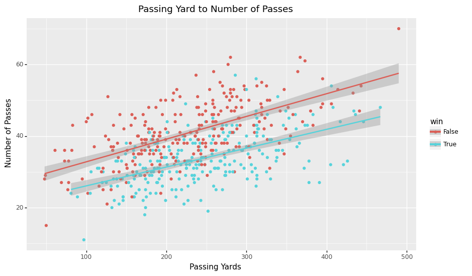

```python
# changes the plot size to be larger, so its easier to read
plotnine.options.figure_size = (10, 6)

#ggplot plots the data with x and y corresponding to a column in the team_data data frame.
#ggplot alows you select a column by color as well, allowing use to see three different variables on the plot
#geom_smoooth with the method='lm' plots a linear regerssion lineon
ggplot(aes(x='pass_yds', y='num_passes', color='win'), data=team_data)  + geom_point() +\
geom_smooth(method='lm') +\
labs(title="Passing Yard to Number of Passes",
         x = "Passing Yards",
         y = "Number of Passes")
```

###### Rushing Yards and Number of Rushes on Winning a Single Game Plot

Let us go ahead and do the same plot for runs and see how it compares!

Below we can see its almost the opposite for runs, with winning teams having more runs for the same yardage until the regression lines almost intersect at 200 yards rushed. This could also be affected by other things such as possessions, team with more time with the ball would have more time to run the ball

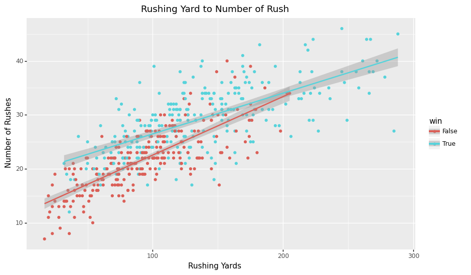

```python
#see comments in last exmaple to understand ggplot
ggplot(aes(x='run_yds', y='num_runs', color='win'), data=team_data)  + geom_point() +\
geom_smooth(method='lm') +\
labs(title="Rushing Yard to Number of Rush",
         x = "Rushing Yards",
         y = "Number of Rushes")
```

###### Model Accuracy

It is common to wonder if you linear model is a good predictor of data, one way to easily see without doing much computation is plotting the residual data. We will use seaborn to plot the residuals. When plotting residuals a sign of a good model is how the data is distributed around the x axis. You want data that is evenly spread on both sides of the x axis

Lets go ahead and plot the residuals.

From the residual plots we can see that for both models, running yards vs number of runs and passing vs passing yards, are equally spread leading me to believe these models are good!

Later on we will use a more concrete computation that tells you how good a model is!

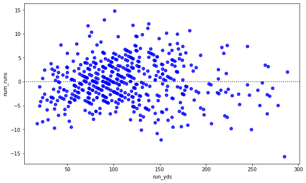

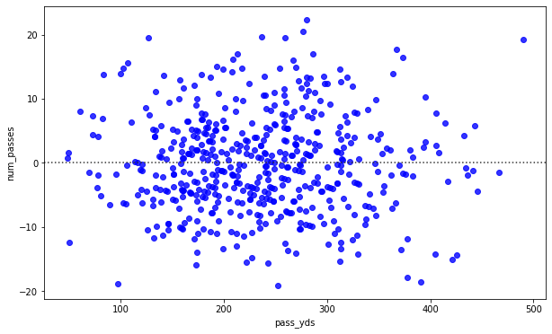

```python
fig_dims = (10, 6)

fig, ax = plt.subplots(figsize=fig_dims)
sns.residplot(team_data['run_yds'],team_data['num_runs'], color='b')


fig_dims = (10, 6)

fig, ax = plt.subplots(figsize=fig_dims)
sns.residplot(team_data['pass_yds'],team_data['num_passes'], color='b')
```

##### Standardization

Another commonly asked question when performing data analysis is whether I need to standardize my data or not. If we take a look at the distribution of teams yardage we can see it has a lot of ups and down but nothing that would make the data skewed, in fact standardization could skew the data incorrectly. The units of data we are using are meaningful and the distance from one another is important.

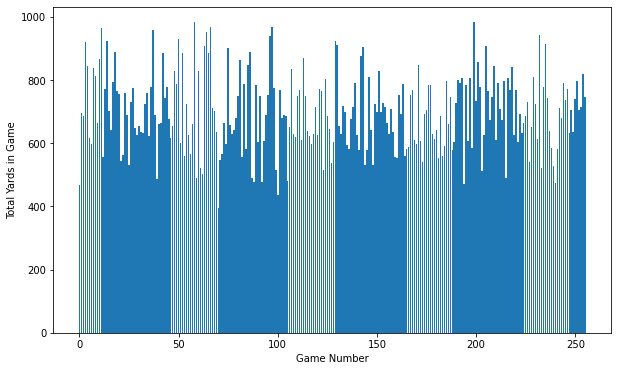

```python
game_data = data2019.groupby(['game_id'])['yards_gained'].sum().reset_index()

plt.bar(game_data.index, game_data['yards_gained'])
plt.gcf().set_size_inches((10,6))
plt.xlabel('Game Number')
plt.ylabel('Total Yards in Game')
```

###### Plotting Team Data Based On Total Values

Lets graph the teams based on their totals stats of the year. This way we can look at performance of the most winning teams, and how rushing and passing affects them.

First things first, we need to regroup our data to represent the year so lets go ahead and do that now

```python
teams_year = team_data.groupby(['teamID'])['win'].value_counts().reset_index(name='wins')
teams_year = teams_year[teams_year['win']==True].reset_index().drop(columns=['win', 'index'])
teams_year = pd.merge(teams_year, team_data.groupby(['teamID'])['pass_yds'].sum().to_frame(), on='teamID')
teams_year = pd.merge(teams_year, team_data.groupby(['teamID'])['run_yds'].sum().to_frame(), on='teamID')
teams_year = pd.merge(teams_year, team_data.groupby(['teamID'])['num_passes'].sum().to_frame(), on='teamID')
teams_year = pd.merge(teams_year, team_data.groupby(['teamID'])['num_runs'].sum().to_frame(), on='teamID')


teams_year.head()
```

|  | teamID | wins | pass_yds | run_yds | num_passes | num_runs |
| --- | --- | --- | --- | --- | --- | --- |
| 0 | ARI | 5 | 3483 | 2007 | 600 | 385 |
| 1 | ATL | 7 | 4718 | 1373 | 737 | 351 |
| 2 | BAL | 14 | 3225 | 3317 | 467 | 575 |
| 3 | BUF | 10 | 3233 | 2069 | 547 | 453 |
| 4 | CAR | 5 | 3650 | 1826 | 689 | 382 |

Now that all of our data is nicely organized lets go ahead and creat a couple plots

# Plotting and Machine Learning

We are going to use linear regression to try which is a better predictor of a team winning, passing or rushing plays. We will plot multiple differnt variants of each and see what the outcome is visually.

We will be using geom_smooth to provide a linear model without any work, here is more information on [geom_smooth](https://plotnine.readthedocs.io/en/stable/generated/plotnine.geoms.geom_smooth.html)

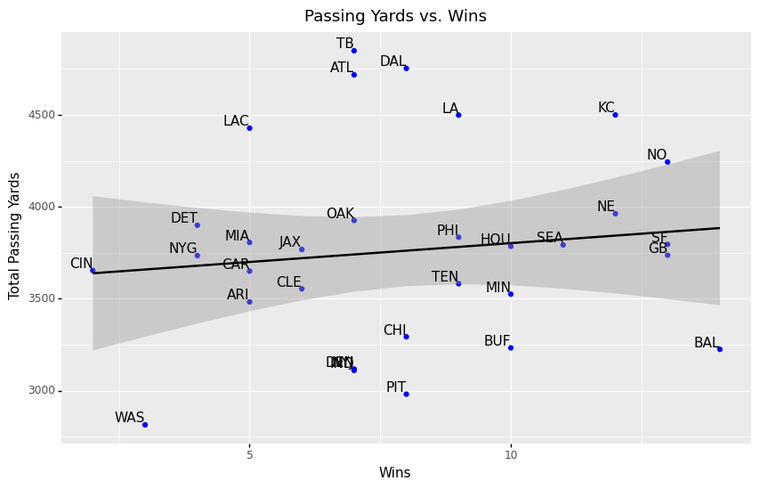

```python
ggplot(aes(x='wins', y='pass_yds'), data=teams_year)  + geom_point(color='blue') +\
geom_smooth(method='lm') +\
labs(title="Passing Yards vs. Wins",
         x = "Wins",
         y = "Total Passing Yards") + geom_text(aes(label='teamID'), ha='right', va='bottom')
```

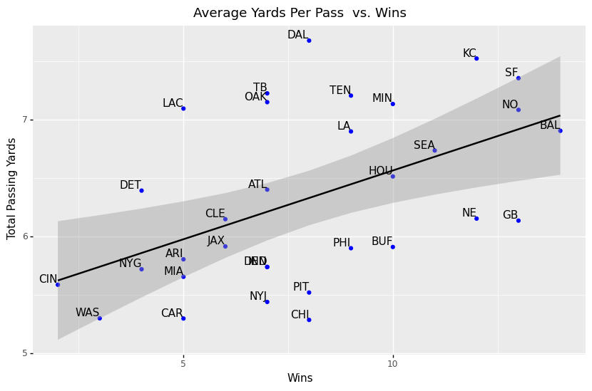

```python
ggplot(aes(x='wins', y='pass_yds/num_passes'), data=teams_year)  + geom_point(color='blue') +\
geom_smooth(method='lm') +\
labs(title="Average Yards Per Pass  vs. Wins",
         x = "Wins",

     y = "Total Passing Yards") + geom_text(aes(label='teamID'), ha='right', va='bottom')
```

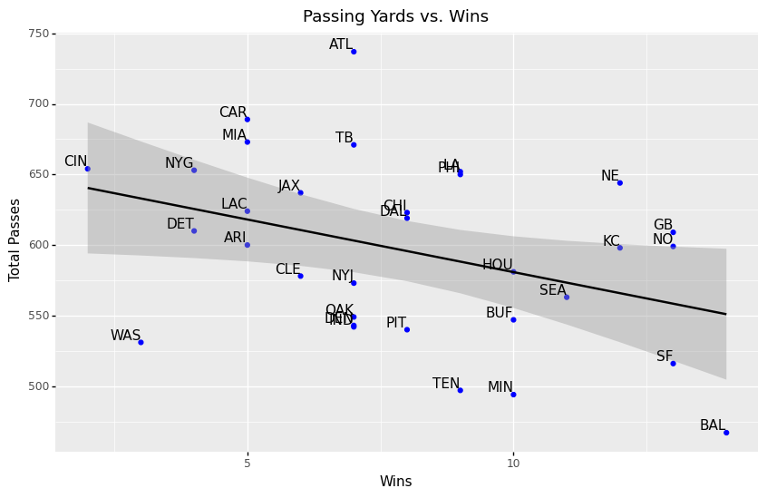

```python
ggplot(aes(x='wins', y='num_passes'), data=teams_year)  + geom_point(color='blue') +\
geom_smooth(method='lm') +\
labs(title="Passing Yards vs. Wins",
         x = "Wins",
         y = "Total Passes") + geom_text(aes(label='teamID'), ha='right', va='bottom')
```

# Graph Evaluation for Passing

Looking throughout the visuals I've noticed some interesting trends that I certainly did not see come. When looking at Rushing and Passing yards we found that rushing seems to be a much, much better predictor.

#### Passing Yards vs Wins analysis

Let’s start off with analyzing the plots looking at passing. The plot ‘Passing Yards vs. Wins’ shows that total passing yards does not make a good predictor with the variance of the data being way to high to make the model accurate.

With a general trend around a couple teams it looks good at the beginning but with to many outliers and such a large 95% confidence internal (the gray shadow coming off the regression line) not touching a lot of the data points it’s safe to say passing yards isn’t a good tell if a team is going to win. There is also hardly any trend upward showing that a small increase in passing yards would increase the number of wins by a lot. This is not accurate.

#### Average Yards Per Pass vs Wins analysis

Plotting yards per pass has a much better plot with a much better-looking regression line, but still lacking an accurate prediction when looking at all the outliers and how far they are still from the confidence interval provided. This would be better to use than strictly total yards. When looking at the data surround the regerssion line it looks to follow the upward trend much better, but the values are still to far.

#### Number of Passes vs Wins analysis

More is not always better and form what this plot shows, more passes is certainly not better. Teams with less over passes had more wins that teams with a lot of passes. For the current season, this predictor works is the most accurate for any predictor involving passes. There maybe another data point that we missed affecting this statistic that we could look at next time.

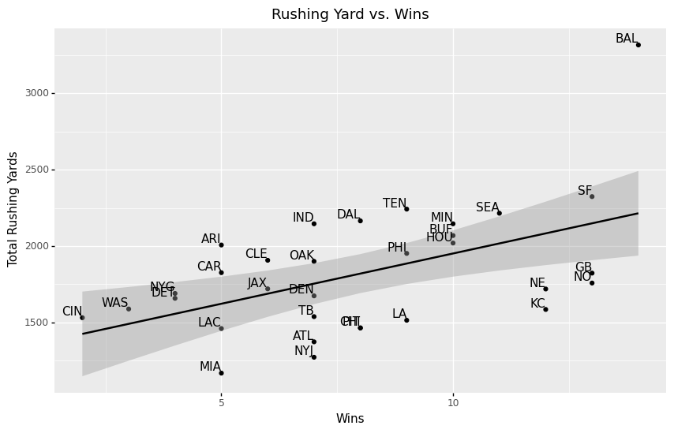

```python
ggplot(aes(x='wins', y='run_yds'), data=teams_year)  + geom_point() +\
geom_smooth(method='lm') +\
labs(title="Rushing Yard vs. Wins",
         x = "Wins",
         y = "Total Rushing Yards") + geom_text(aes(label='teamID'), ha='right', va='bottom')
```

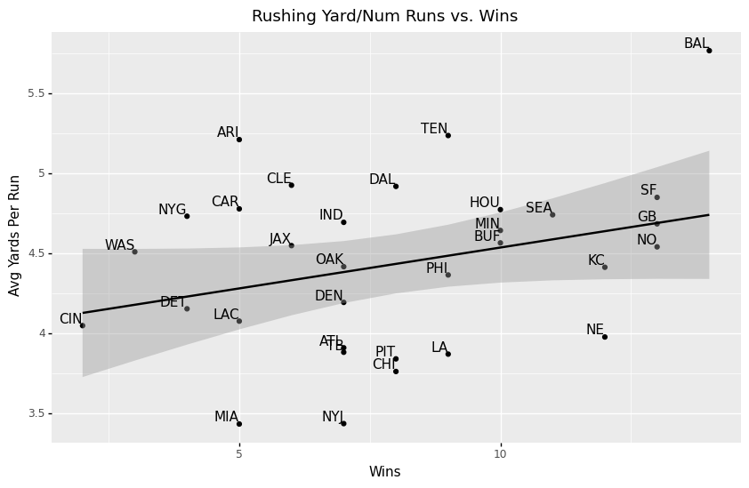

```python
ggplot(aes(x='wins', y='run_yds/num_runs'), data=teams_year)  + geom_point() +\
geom_smooth(method='lm') +\
labs(title="Rushing Yard/Num Runs vs. Wins",
         x = "Wins",
         y = "Avg Yards Per Run") + geom_text(aes(label='teamID'), ha='right', va='bottom')
```

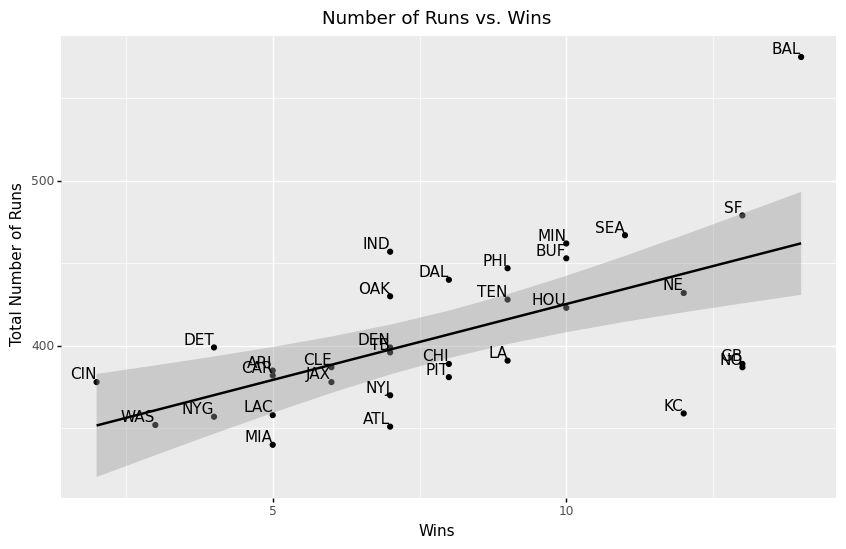

```python
ggplot(aes(x='wins', y='num_runs'), data=teams_year)  + geom_point() +\
geom_smooth(method='lm') +\
labs(title="Number of Runs vs. Wins",
         x = "Wins",
         y = "Total Number of Runs") + geom_text(aes(label='teamID'), ha='right', va='bottom')
```

# Graph Evaluation for Rushing

###### Total Rushing Yards vs. Wins

When looking at Total Rushes this looks like a very accurate predictor with our data points following the line very well. This would be the predictor to use if we could do no further investigating

###### Average Rushing Yards Per Carry vs. Wins

This plot is very similar to the previous but stretched out, with alot of the data still representing the model somewhat.

###### Number of Runs vs. Wins

When looking at the last graph it seems that yardage isn't even the important a factor looking into wins. Just looking at the number of times a team tried to run the ball predicts very well where they will land in terms of wins. This may be due to data we miss during analysis, like completions depending on play type.

```python
teams_year.head()
```

|  | teamID | wins | pass_yds | run_yds | num_passes | num_runs |
| --- | --- | --- | --- | --- | --- | --- |
| 0 | ARI | 5 | 3483 | 2007 | 600 | 385 |
| 1 | ATL | 7 | 4718 | 1373 | 737 | 351 |
| 2 | BAL | 14 | 3225 | 3317 | 467 | 575 |
| 3 | BUF | 10 | 3233 | 2069 | 547 | 453 |
| 4 | CAR | 5 | 3650 | 1826 | 689 | 382 |

# Machine Learning and Modeling

First lets go ahead and look at run yards as that looks to be the most promising single value predictor! We need to hot encode the data for team so they can be processed by the model. Hot encoding turns strings into a numeric value that can go through the functions.

We are using statsmodels for regression, click [here](https://www.statsmodels.org/stable/index.html) for more info

##### Linear Model using only Rushing Yards

From this module using only run_yds we get a good linear model with an R^2 value of .903 which means the model is reliable!

OLS Regression Results

| Dep. Variable: | wins | R-squared (uncentered): | 0.903 |
| --- | --- | --- | --- |
| Model: | OLS | Adj. R-squared (uncentered): | 0.900 |
| Method: | Least Squares | F-statistic: | 288.3 |
| Date: | Tue, 21 Jul 2020 | Prob (F-statistic): | 2.98e-17 |
| Time: | 23:58:13 | Log-Likelihood: | -76.889 |
| No. Observations: | 32 | AIC: | 155.8 |
| Df Residuals: | 31 | BIC: | 157.2 |
| Df Model: | 1 |  |  |
| Covariance Type: | nonrobust |  |  |

|  | coef | std err | t | P>\|t\| | [0.025 | 0.975] |
| --- | --- | --- | --- | --- | --- | --- |
| run_yds | 0.0044 | 0.000 | 16.979 | 0.000 | 0.004 | 0.005 |

| Omnibus: | 0.824 | Durbin-Watson: | 1.878 |
| --- | --- | --- | --- |
| Prob(Omnibus): | 0.662 | Jarque-Bera (JB): | 0.873 |
| Skew: | 0.270 | Prob(JB): | 0.646 |
| Kurtosis: | 2.397 | Cond. No. | 1.00 |

Warnings:  
[1] Standard Errors assume that the covariance matrix of the errors is correctly specified.

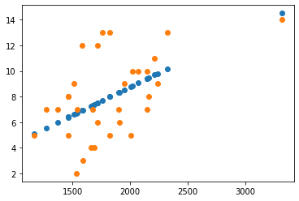

```python
# hot encode our data
hot_encoded_id = [x for x in range((len(teams_year['teamID'])))]

# create a new variable so I can chop it up without affecting the original data set
regression_set = teams_year
regression_set['teamID'] = hot_encoded_id
# lets remove our wins from our data set, we don't want to use that in training! Thats what we want to find
X = regression_set.drop('wins', axis = 1)
# make our y values which we will train to achieve with the passed in columns
Y = regression_set[['wins']]

#our values to train with, currently just the run_yds
X2 = X[['run_yds']]

#create the model which takes in the training set and the learning data
model = sm.OLS(Y,X2)

# lets go ahead and fit the model
estimate = model.fit()

# turn it into a frame so we can easily use matlibplot to create a visual
Y_ = estimate.predict(X2).to_frame()

plt.scatter(X2['run_yds'], Y_)
plt.scatter(teams_year['run_yds'], teams_year['wins'])

estimate.summary()
```

###### Multiple Regression Model with Rush Yards and Number of Rushes

OLS Regression Results

| Dep. Variable: | wins | R-squared (uncentered): | 0.907 |
| --- | --- | --- | --- |
| Model: | OLS | Adj. R-squared (uncentered): | 0.901 |
| Method: | Least Squares | F-statistic: | 146.0 |
| Date: | Tue, 21 Jul 2020 | Prob (F-statistic): | 3.46e-16 |
| Time: | 23:58:13 | Log-Likelihood: | -76.231 |
| No. Observations: | 32 | AIC: | 156.5 |
| Df Residuals: | 30 | BIC: | 159.4 |
| Df Model: | 2 |  |  |
| Covariance Type: | nonrobust |  |  |

|  | coef | std err | t | P>\|t\| | [0.025 | 0.975] |
| --- | --- | --- | --- | --- | --- | --- |
| run_yds | 0.0020 | 0.002 | 0.929 | 0.360 | -0.002 | 0.006 |
| num_runs | 0.0109 | 0.010 | 1.122 | 0.271 | -0.009 | 0.031 |

| Omnibus: | 0.637 | Durbin-Watson: | 1.849 |
| --- | --- | --- | --- |
| Prob(Omnibus): | 0.727 | Jarque-Bera (JB): | 0.673 |
| Skew: | 0.297 | Prob(JB): | 0.714 |
| Kurtosis: | 2.610 | Cond. No. | 39.8 |

Warnings:  
[1] Standard Errors assume that the covariance matrix of the errors is correctly specified.

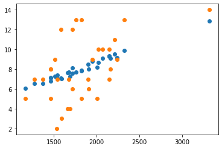

```python
# hot encode our data
hot_encoded_id = [x for x in range((len(teams_year['teamID'])))]

# create a new variable so I can chop it up without affecting the original data set
regression_set = teams_year
regression_set['teamID'] = hot_encoded_id
# lets remove our wins from our data set, we don't want to use that in training! Thats what we want to find
X = regression_set.drop('wins', axis = 1)
# make our y values which we will train to achieve with the passed in columns
Y = regression_set[['wins']]

#our values to train with, we are now using two variables to train on
X2 = X[['run_yds', 'num_runs']]

#create the model which takes in the training set and the learning data
model = sm.OLS(Y,X2)

# lets go ahead and fit the model
estimate = model.fit()

# turn it into a frame so we can easily use matlibplot to create a visual
Y_ = estimate.predict(X2).to_frame()

plt.scatter(X2['run_yds'], Y_)
plt.scatter(teams_year['run_yds'], teams_year['wins'])

estimate.summary()
```

###### Multiple Regression Model with Passing Yards

Looking at the summary and plot below we can see that passing yards is a worse predictor of wins, we assumed this earlier by looking visually at the plots.

OLS Regression Results

| Dep. Variable: | wins | R-squared (uncentered): | 0.863 |
| --- | --- | --- | --- |
| Model: | OLS | Adj. R-squared (uncentered): | 0.859 |
| Method: | Least Squares | F-statistic: | 195.9 |
| Date: | Tue, 21 Jul 2020 | Prob (F-statistic): | 6.06e-15 |
| Time: | 23:58:13 | Log-Likelihood: | -82.354 |
| No. Observations: | 32 | AIC: | 166.7 |
| Df Residuals: | 31 | BIC: | 168.2 |
| Df Model: | 1 |  |  |
| Covariance Type: | nonrobust |  |  |

|  | coef | std err | t | P>\|t\| | [0.025 | 0.975] |
| --- | --- | --- | --- | --- | --- | --- |
| pass_yds | 0.0021 | 0.000 | 13.997 | 0.000 | 0.002 | 0.002 |

| Omnibus: | 1.492 | Durbin-Watson: | 2.005 |
| --- | --- | --- | --- |
| Prob(Omnibus): | 0.474 | Jarque-Bera (JB): | 1.138 |
| Skew: | 0.221 | Prob(JB): | 0.566 |
| Kurtosis: | 2.188 | Cond. No. | 1.00 |

Warnings:  
[1] Standard Errors assume that the covariance matrix of the errors is correctly specified.

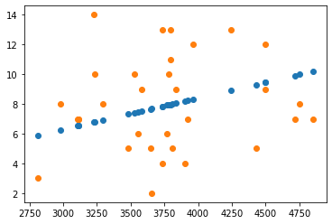

```python
# hot encode our data
hot_encoded_id = [x for x in range((len(teams_year['teamID'])))]

# create a new variable so I can chop it up without affecting the original data set
regression_set = teams_year
regression_set['teamID'] = hot_encoded_id
# lets remove our wins from our data set, we don't want to use that in training! Thats what we want to find
X = regression_set.drop('wins', axis = 1)
# make our y values which we will train to achieve with the passed in columns
Y = regression_set[['wins']]

#our values to train with, we are now using two variables to train on
X2 = X[['pass_yds']]

#create the model which takes in the training set and the learning data
model = sm.OLS(Y,X2)

# lets go ahead and fit the model
estimate = model.fit()

# turn it into a frame so we can easily use matlibplot to create a visual
Y_ = estimate.predict(X2).to_frame()

plt.scatter(X2['pass_yds'], Y_)
plt.scatter(teams_year['pass_yds'], teams_year['wins'])

estimate.summary()
```

###### Multiple Regression Model with Passing Yards and Number of Passes

Theres no real improvement in the when using pass_yds and num_passes together

OLS Regression Results

| Dep. Variable: | wins | R-squared (uncentered): | 0.872 |
| --- | --- | --- | --- |
| Model: | OLS | Adj. R-squared (uncentered): | 0.863 |
| Method: | Least Squares | F-statistic: | 101.8 |
| Date: | Tue, 21 Jul 2020 | Prob (F-statistic): | 4.24e-14 |
| Time: | 23:58:13 | Log-Likelihood: | -81.360 |
| No. Observations: | 32 | AIC: | 166.7 |
| Df Residuals: | 30 | BIC: | 169.7 |
| Df Model: | 2 |  |  |
| Covariance Type: | nonrobust |  |  |

|  | coef | std err | t | P>\|t\| | [0.025 | 0.975] |
| --- | --- | --- | --- | --- | --- | --- |
| pass_yds | 0.0039 | 0.001 | 2.987 | 0.006 | 0.001 | 0.007 |
| num_passes | -0.0115 | 0.008 | -1.387 | 0.176 | -0.028 | 0.005 |

| Omnibus: | 1.638 | Durbin-Watson: | 2.044 |
| --- | --- | --- | --- |
| Prob(Omnibus): | 0.441 | Jarque-Bera (JB): | 1.073 |
| Skew: | 0.096 | Prob(JB): | 0.585 |
| Kurtosis: | 2.124 | Cond. No. | 57.3 |

Warnings:  
[1] Standard Errors assume that the covariance matrix of the errors is correctly specified.

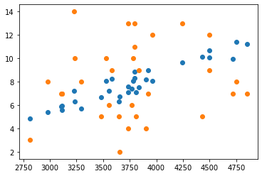

```python
hot_encoded_id = [x for x in range((len(teams_year['teamID'])))]
regression_set = teams_year
regression_set['teamID'] = hot_encoded_id
X = regression_set.drop('wins', axis = 1)
Y = regression_set[['wins']]
X2 = X[['pass_yds', 'num_passes']]
model = sm.OLS(Y,X2)
estimate = model.fit()
Y_ = estimate.predict(X2).to_frame()
plt.scatter(X2['pass_yds'], Y_)
plt.scatter(teams_year['pass_yds'], teams_year['wins'])
estimate.summary()
```

###### Multiple Regression Model with Running Yards, Number of Runs, Number of Passes

I went ahead and checked for the best model using run_yds, passing_yds, num_passes, and num_runs and found that including the passing yards overcorrects the module giving less accurate results that using the 3 other variables. This is currently the best module for predicting wins based play type and yardage.

OLS Regression Results

| Dep. Variable: | wins | R-squared (uncentered): | 0.914 |
| --- | --- | --- | --- |
| Model: | OLS | Adj. R-squared (uncentered): | 0.905 |
| Method: | Least Squares | F-statistic: | 102.9 |
| Date: | Tue, 21 Jul 2020 | Prob (F-statistic): | 1.47e-15 |
| Time: | 23:58:13 | Log-Likelihood: | -74.928 |
| No. Observations: | 32 | AIC: | 155.9 |
| Df Residuals: | 29 | BIC: | 160.3 |
| Df Model: | 3 |  |  |
| Covariance Type: | nonrobust |  |  |

|  | coef | std err | t | P>\|t\| | [0.025 | 0.975] |
| --- | --- | --- | --- | --- | --- | --- |
| num_runs | 0.0360 | 0.019 | 1.936 | 0.063 | -0.002 | 0.074 |
| run_yds | -0.0009 | 0.003 | -0.328 | 0.745 | -0.007 | 0.005 |
| num_passes | -0.0083 | 0.005 | -1.569 | 0.128 | -0.019 | 0.003 |

| Omnibus: | 3.715 | Durbin-Watson: | 1.848 |
| --- | --- | --- | --- |
| Prob(Omnibus): | 0.156 | Jarque-Bera (JB): | 2.487 |
| Skew: | 0.659 | Prob(JB): | 0.288 |
| Kurtosis: | 3.357 | Cond. No. | 82.4 |

Warnings:  
[1] Standard Errors assume that the covariance matrix of the errors is correctly specified.

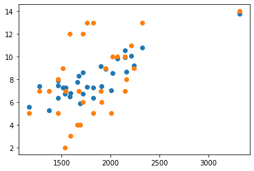

```python
hot_encoded_id = [x for x in range((len(teams_year['teamID'])))]
regression_set = teams_year
regression_set['teamID'] = hot_encoded_id
X = regression_set.drop('wins', axis = 1)
Y = regression_set[['wins']]
X2 = X[['num_runs', 'run_yds', 'num_passes']]
model = sm.OLS(Y,X2)
estimate = model.fit()
Y_ = estimate.predict(X2).to_frame()
plt.scatter(X2['run_yds'], Y_)
plt.scatter(teams_year['run_yds'], teams_year['wins'])

estimate.summary()
```

# Conclusion

In my analysis of rushing plays vs passing plays I have learned that there are many more factors than need to be taken into account, yet with such simple data points we can somewhat accurately depict how many times a team will win given there isn’t a large change in trends in upcoming seasons. I learned a lot about the NLF types of plays and actual performance of teams and how they relate to play picks.

Throughout the entire project there was much evidence that running the ball was a much better option than passing, given the data and visuals. Looking through the rest of the project I believe that more characteristics of a play could be incorporated into the models for a more accurate prediction. For now, I wanted to do a deep dive in the basics and show how much you can learn from the basics play types. Looking through the data for each play-by-play with 256 columns I’ve realized in the future I could incorporate more data to make a more accurate model, basing plays off field positioning, what down it is, etc. Overall I really enjoyed this project and will continue using this knowledge to create models to solve problems I face in the real world.